# gapminder extra

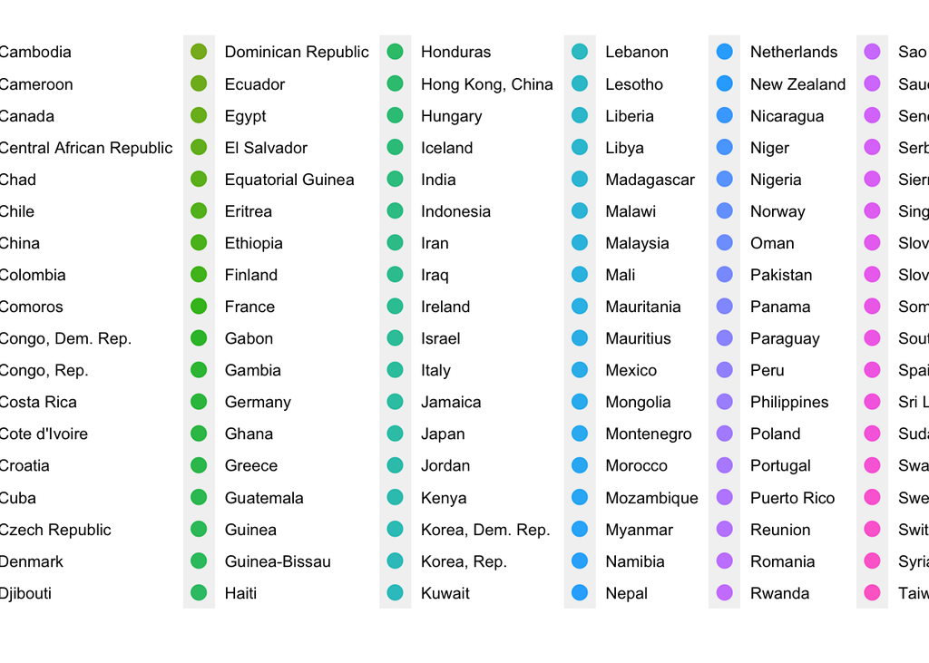

```r
gapminder %>%
  filter(year == 2007) %>%
  ggplot(aes(log(gdpPercap), lifeExp)) +
  geom_point(
    aes(color = country),
    size = 3.5,
    alpha = .9)
```

The legend overtakes our plot and become really difficult to understand. Instead of overloading our plots we should strive to simplify the aesthetics and when at all possible design without using legends. We can do this with direct labelling. To label the plot we’ll use the `ggrepel` package. It give us two functions: `geom_text_repel()` & `geom_label_repel()`.`geom_text_repel` adds text directly to the plot. It takes an argument for mapping what we want to annotate. Here, we’ll add an `aes` of label for country. We’ll also change the size of the dots, set a transparency (alpha), add a color and fill. What does color do? Fill? Yes, colors around the edge of the dots and fill fills the dot with color. We’ll use the UCLA blue for the color.

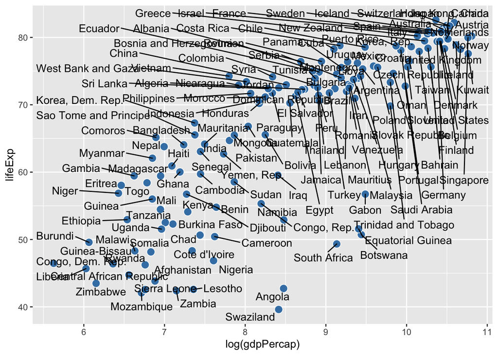

Still very busy. Next, we want to subset the data by 10 countries to reduce the cognitive load on the graph. We can do this any number of ways, but here we’ll use the `sample()` function to randomly select ten countries. We’ll also use the `set.seed()` function so it sets our countries to the same 10 countries if we rerun the function. If you want different set of 10 countries each time you run the code, remove or comment out the `set.seed()` line.

```r
set.seed(42)

ten_countries <- gapminder$country %>%
  levels() %>%
  sample(10)

ten_countries
```

```
##  [1] "Ghana"       "Italy"       "Lesotho"     "Swaziland"   "Zimbabwe"
##  [6] "Thailand"    "Gambia"      "Chile"       "Korea, Rep." "Paraguay"
```

Next step is to use the `ten_countries` vector to create a new variable in our dataframe that will become the countries we label the plot with. So, in the `mutate()` function, we check if each country is one of the countries in `ten_countries`. If it’s not, make that label row an empty string (""). If it is, we add the country to that row as a character. I’ll assign the output of this code to a new called `gapminder_label`.

```r
gapminder_label <- gapminder %>%
  filter(year == 2007) %>%
  mutate(label = ifelse(country %in% ten_countries, as.character(country), ""))
```

Let’s look at the data. Click Next on the code chunk output in Rmarkdown until you see a country in the `label` column.

```r
gapminder_label
```

```
## # A tibble: 142 x 7
##    country     continent  year lifeExp       pop gdpPercap label
##    <fct>       <fct>     <int>   <dbl>     <int>     <dbl> <chr>
##  1 Afghanistan Asia       2007    43.8  31889923      975. ""
##  2 Albania     Europe     2007    76.4   3600523     5937. ""
##  3 Algeria     Africa     2007    72.3  33333216     6223. ""
##  4 Angola      Africa     2007    42.7  12420476     4797. ""
##  5 Argentina   Americas   2007    75.3  40301927    12779. ""
##  6 Australia   Oceania    2007    81.2  20434176    34435. ""
##  7 Austria     Europe     2007    79.8   8199783    36126. ""
##  8 Bahrain     Asia       2007    75.6    708573    29796. ""
##  9 Bangladesh  Asia       2007    64.1 150448339     1391. ""
## 10 Belgium     Europe     2007    79.4  10392226    33693. ""
## # … with 132 more rows
```

Ok, we have a new dataframe with a column for the countries we want to add labels for dots on our scatterplot. We can now use this dataframe to label the graph.

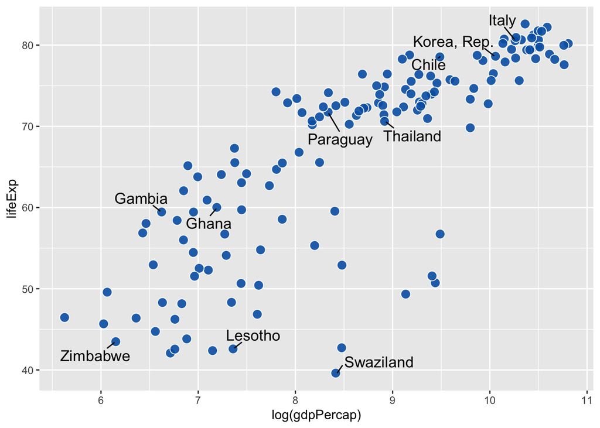

```r
gapminder_label %>%
  ggplot(aes(log(gdpPercap), lifeExp)) +
  geom_point(size = 3.5,
             alpha = .9,
             shape = 21,
             col = "white",
             fill = "#0162B2"
) +
  geom_text_repel(aes(label = label), size = 4.5, point.padding = .2, box.padding = .3, force = 1, min.segment.length = 0)
```

This is a much easier graph to understand. Let’s clean it up a bit by adjusting the grid, theme and labels.

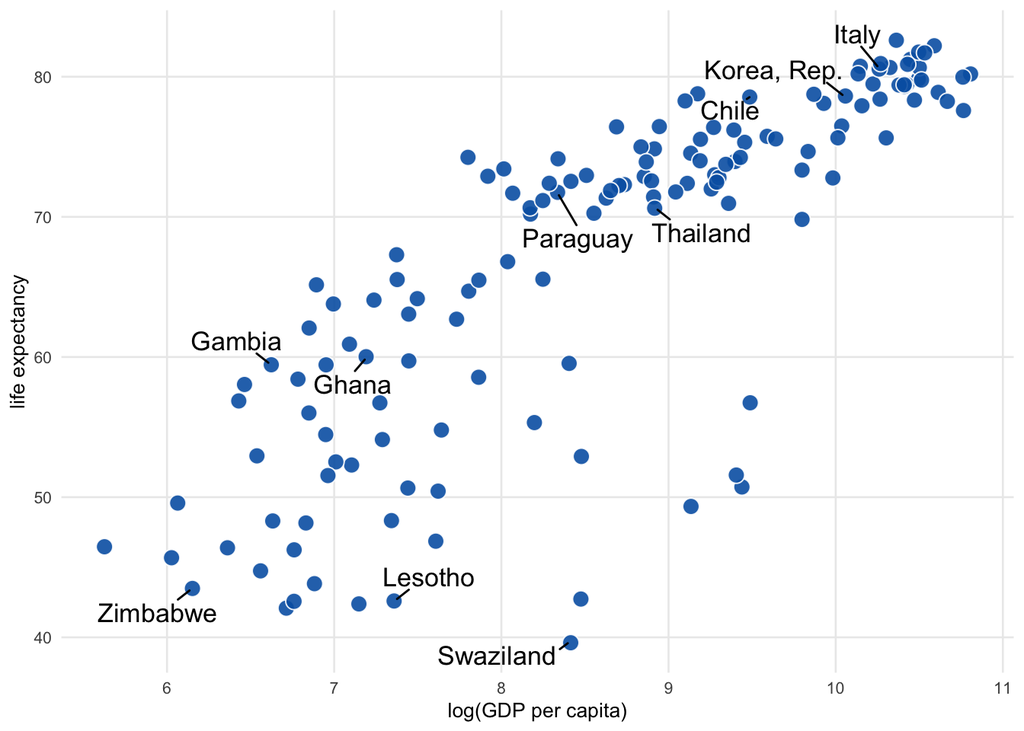

```r
gapminder_label %>%
  ggplot(aes(log(gdpPercap), lifeExp)) +
  geom_point(size = 3.5,
             alpha = .9,
             shape = 21,
             col = "white",
             fill = "#0162B2"
) +
  geom_text_repel(aes(label = label), size = 4.5, point.padding = .2, box.padding = .3, force = 1, min.segment.length = 0) +
  theme_minimal(10) +
  theme(legend.position = "none", panel.grid.minor = element_blank()
) +
  labs( x = "log(GDP per capita)", y = "life expectancy")
```

Ok, next step might be to change the countries. Say you want to specify ten countries manually? How would you go about this?